# MY472 - Assignment 5

```r
suppressMessages(library(quanteda))
```

```r
suppressMessages(library(dplyr))
suppressMessages(library(readtext))
suppressMessages(library(DBI))
suppressMessages(library(compare))
suppressMessages(library(RSQLite))
suppressMessages(library(quanteda.textplots))
```

**Exercise 1. (23 points)**

In this exercise, you will build a database containing political tweets from the time of the 2017 UK General Election campaign. The tweet data can be downloaded from this dropbox [link](https://www.dropbox.com/sh/ktl1a3672yl6te0/AAA2At9pSt9hZ-KsaT0Mwbp2a?dl=0). The files contain tweets from candidates and parties, and replies to these accounts.

Note that the files in the dropbox link are compressed. Information on candidates, parties and associated Twitter accounts can be found in “candidate_information.csv” in the repo. This e.g. allows you to find out which tweets and users belong to politicians/parties and which ones are replies from other users, but the file also contains other information.

There are 113 tar.gz files in the dropbox folder containing JSON files with both tweets and user information. All files have to be processed into a relational database (use `DBI` with `SQLite` to create and query this database). There can be several strategies to read the files into R, one is to use the `readtext` function from the `readtext` package which can read compressed files directly (hint: you should also check out the `source` argument in this function which has an option tailored directly to Twitter data).

The goal is to separate the fields in the JSON documents containing tweet and user information into two tables of a relational database. You can name these tables `tweets` and `users`. Before you write the tables into your database, you can process the tweet data with `dplyr` or other packages. Make sure that there are no duplicates among the users and tweets in the final database (i.e. the tweet id is **unique** in the `tweets` table, and the user id is **unique** in `users` table). Also make sure that these two tables can be combined afterwards using a column common to the tables. Please also add one indicator column (i.e. either TRUE/FALSE or 1/0) to each of your tables, in detail:

- A column “screen_name_in” in the `users` table indicating whether an account is among the politician/party accounts
- A column “in_reply_to_screen_name_in” in the `tweets` table indicating whether a tweet was a reply to a politician/party account

(Hint: You can use the file “candidate_information.csv” to determine which users and tweets are from the politicians/parties and which ones are not)

Make sure that the two final tables in the database contain only one suitable merging column and no unnecessary duplicated information.

1.1 Create a relational `SQLite` database containing the two tables `users` and `tweets`. Once the database has been created, use SQL queries to:

1.2 Print out the total number of rows of each table.

1.3 Print out all column names of each table.

1.4 Print out the first five rows of each table.

1.5 Print out the first five rows of the joined table.

Then disconnect again from your database (in the next exercise we will use a different database).

**Important note:** Please store the files with tweets and your database outside this repo. We will grade the knitted HTML document and do not require these large files. Furthermore, processing the files will take some time, so it is normal that knitting the final document takes time. Do not load data from interim steps but make sure your code fully creates a database in Exercise 1 from the `ge2017` folder when knitting.

```r
# 1.1
# Create database
db1 <- dbConnect(RSQLite::SQLite(), "~/downloads/ge2017/assignment05.sqlite")
candi <- read.csv("candidate_information.csv")

# Reading the all the files into R
text <- readtext('~/downloads/ge2017.zip',ignore_missing_files=TRUE,text_field = NULL,source = "twitter")

# Extract 15 columns related to tweets, eliminate the same data
tweets_tp <- text[,c(1:15,18)] %>%
  distinct(id_str,.keep_all = TRUE)

# Add one indicator column
tweets <- as.data.frame(mutate(tweets_tp, in_reply_to_screen_name_in = tweets_tp$in_reply_to_screen_name %in% candi$screenName))

# Extract the other columns related to users, eliminate the same data
users_tp <- text[,c(16:44)] %>%
  distinct(user_id_str,.keep_all = TRUE)

# Add one indicator column
users <- as.data.frame(mutate(users_tp, screen_name_in = users_tp$screen_name %in% candi$screenName))

# use to remove
#dbRemoveTable(db1, "tweets")
#dbRemoveTable(db1, "users")

# Write table
dbWriteTable(db1, "tweets", tweets)
dbWriteTable(db1, "users", users)


# 1.2
# Return the total number of rows 、
dbGetQuery(db1, "SELECT COUNT(*) FROM tweets")
```

```
##   COUNT(*)
## 1   221680
```

```r
dbGetQuery(db1, "SELECT COUNT(*) FROM users")
```

```
##   COUNT(*)
## 1    91256
```

```r
# 1.3
# Print out all column names
dbListFields(db1, "tweets")
```

```
##  [1] "doc_id"                     "text"
##  [3] "retweet_count"              "favorite_count"
##  [5] "favorited"                  "truncated"
##  [7] "id_str"                     "in_reply_to_screen_name"
##  [9] "source"                     "retweeted"
## [11] "created_at"                 "in_reply_to_status_id_str"
## [13] "in_reply_to_user_id_str"    "lang"
## [15] "listed_count"               "user_id_str"
## [17] "in_reply_to_screen_name_in"
```

```r
dbListFields(db1, "users")
```

```
##  [1] "verified"         "location"         "user_id_str"      "description"
##  [5] "geo_enabled"      "user_created_at"  "statuses_count"   "followers_count"
##  [9] "favourites_count" "protected"        "user_url"         "name"
## [13] "time_zone"        "user_lang"        "utc_offset"       "friends_count"
## [17] "screen_name"      "country_code"     "country"          "place_type"
## [21] "full_name"        "place_name"       "place_id"         "place_lat"
## [25] "place_lon"        "lat"              "lon"              "expanded_url"
## [29] "url"              "screen_name_in"
```

```r
# 1.4
# Print out the first five rows
dbGetQuery(db1, "SELECT * FROM tweets LIMIT 5")
```

```
##                          doc_id
## 1 tw_json_6_201705311400.json.1
## 2 tw_json_6_201705311400.json.2
## 3 tw_json_6_201705311400.json.3
## 4 tw_json_6_201705311400.json.4
## 5 tw_json_6_201705311400.json.5
##                                                                                                                                                                                        text
## 1                                                                                                                                       RT @jonisabear: @johnleechmcr Yes! Excellent stuff.
## 2                                             RT @TheGreenParty: Our schools are in crisis. Why? A Govt that prioritises tax cuts for the rich over spending that benefits all of us. htt…
## 3  @dean_r @gavinshuker @jeremycorbyn @theresa_may Would love to support, but your CV reads like a 'Get out of work at any cost' self-help pamphlet. Same with Shuker, so you're not alone.
## 4                                             RT @LibDems: .@nick_clegg Up to 250k kids living in poverty across England will have their lunches taken away under May's plans https://t.c…
## 5 RT @jeremycorbyn:.@Theresa_May come &amp; debate me. Any time. Any place. Britain deserves to see the only two people who could be the next Prime Minister debate https://t.co/hM6wK9e32B
##   retweet_count favorite_count favorited truncated             id_str
## 1             2              1         0         0 869912602574548996
## 2            53             30         0         0 869912604201938945
```

[output cut: 33 more lines]

```r
dbGetQuery(db1, "SELECT * FROM users LIMIT 5")
```

```
##   verified            location        user_id_str
## 1        0                <NA> 795301881551654917
## 2        0  Liverpool, England         1014064806
## 3        0 27^59'17N 86^55'31E          290509530
## 4        0                <NA>          756890449
## 5        0                <NA> 747716358876577793
##                                                                                                                                                   description
## 1 Latest news, updates and opinions from across the Lib Dem spectrum and beyond. Not official. RT≠endorsement. Unmoderated. Also see @labour_zone @tory_zone
## 2                                     Lawrence Brown, Prospective Parliamentary Candidate for Garston and Halewood, Councillor for Greenbank ward, Liverpool.
## 3                                                                                              History. Anarchy. Research & writing, history, economics, law.
## 4                               Dedicated to Lime Poppy and Birmingham City, and to the abolition of jingoism, unearned privilege and the misuse of literally
## 5                                          Londoner, DIY Activist, Democratic Socialist. Feminist, Intersectionalist & Anti Fascist. Humorous (but seriously)
##   geo_enabled                user_created_at statuses_count followers_count
## 1           0 Sun Nov 06 16:28:39 +0000 2016          44595             720
## 2           0 Sat Dec 15 22:55:43 +0000 2012           1497             468
```

[output cut: 39 more lines]

```r
# 1.5
# Print out the first five rows of the joined table
dbGetQuery(db1, "SELECT *
           FROM tweets
           JOIN users
           ON tweets.user_id_str = users.user_id_str
           LIMIT 5")
```

```
##                          doc_id
## 1 tw_json_6_201705311400.json.1
## 2 tw_json_6_201705311400.json.2
## 3 tw_json_6_201705311400.json.3
## 4 tw_json_6_201705311400.json.4
## 5 tw_json_6_201705311400.json.5
##                                                                                                                                                                                        text
## 1                                                                                                                                       RT @jonisabear: @johnleechmcr Yes! Excellent stuff.
## 2                                             RT @TheGreenParty: Our schools are in crisis. Why? A Govt that prioritises tax cuts for the rich over spending that benefits all of us. htt…
## 3  @dean_r @gavinshuker @jeremycorbyn @theresa_may Would love to support, but your CV reads like a 'Get out of work at any cost' self-help pamphlet. Same with Shuker, so you're not alone.
## 4                                             RT @LibDems: .@nick_clegg Up to 250k kids living in poverty across England will have their lunches taken away under May's plans https://t.c…
## 5 RT @jeremycorbyn:.@Theresa_May come &amp; debate me. Any time. Any place. Britain deserves to see the only two people who could be the next Prime Minister debate https://t.co/hM6wK9e32B
##   retweet_count favorite_count favorited truncated             id_str
## 1             2              1         0         0 869912602574548996
## 2            53             30         0         0 869912604201938945
```

[output cut: 81 more lines]

```r
# Disconnect
dbDisconnect(db1)
```

**Exercise 2. (35 points)**

**Important note:** In this exercise **do not** use your previous database. Instead use the database `uk_election_tweets_small.sqlite` which is supplied in the assignment repo! Answer questions 2.1 - 2.9 using **SQL syntax only** (sending SQL statements through R is fine, no need to change chunk types).

Connect to `uk_election_tweets_small.sqlite`:

```r
db2 <- dbConnect(RSQLite::SQLite(),"uk_election_tweets_small.sqlite")
```

2.1 How many tweets are in the `tweets` table? How many users in the `users` table? (1 point)

```r
# Check the construction of the two tables
dbGetQuery(db2, "SELECT * FROM tweets LIMIT 5")
```

```
##                           doc_id
## 1  tw_json_6_201705261745.json.1
## 2  tw_json_6_201705261745.json.8
## 3  tw_json_6_201705261745.json.9
## 4 tw_json_6_201705261745.json.10
## 5 tw_json_6_201705261745.json.20
##                                                                                                                                           text
## 1                              RT @BenRich66: If you work in tech and are backing @libdems then this will interest you https://t.co/tWDj1dWU6R
## 2                                               Lib Dems would give Humberside Police force an extra £4,470,000 a year https://t.co/0ch7klC74G
## 3    Less than 2 weeks until #GE2017. Team #Cherry4EdinSW are campaigning at Westside Plaza tomorrow at 10AM. Join us! https://t.co/B6P6dJiUIp
## 4                                                 Why people are voting Labour in Harborough #GE17 #Labour #Harborough https://t.co/0E1DJPaB8V
## 5 RT @wallaceme: Corbyn's case is that "terrorists...will never prevail", but let's change our foreign policy because they dislike it. Which…
##   retweet_count favorite_count favorited truncated             id_str
## 1             1              0         0         0 868157285226491905
## 2             0              0         0         0 868157302800605185
```

[output cut: 33 more lines]

```r
dbGetQuery(db2, "SELECT * FROM users LIMIT 5")
```

```
##   verified            location user_id_str
## 1        0 Mostly in Liverpool    20255744
## 2        0             Grimsby    39032403
## 3        1 Edinburgh, Scotland  2583270112
## 4        0   Market Harborough  2912699739
## 5        0      Ealing, London   259707048
##                                                                                                                                         description
## 1           Leader Liverpool Lib Dems, Lib Dem Spokesperson on health and social care, LGA. Lib Dem Parliamentary Candidate for Liverpool Wavertree
## 2              Liberal Democrat Candidate for Great Grimsby and Councillor for the East Marsh Ward - Community Politician (serving local residents)
## 3                               SNP candidate for Edinburgh South West, SNP Spokesperson on Justice and Home Affairs, Queen's Counsel and Feminist.
## 4 PPC: (Harborough constituency): Andy Thomas. Campaigning to make Britain a better fairer place. This account is run on behalf of Andy's campaign.
## 5                           Conservative Parliamentary Candidate for Ealing North GE June 8 2017. Chartered Civil Engineer. Local mum and activist.
##   geo_enabled                user_created_at statuses_count followers_count
## 1           1 Fri Feb 06 17:54:34 +0000 2009          42343            3914
## 2           1 Sun May 10 11:17:11 +0000 2009         174565            3429
```

[output cut: 39 more lines]

```r
# Count each of them
dbGetQuery(db2, "SELECT COUNT(*) FROM tweets")
```

```
##   COUNT(*)
## 1    22130
```

```r
dbGetQuery(db2, "SELECT COUNT(*) FROM users")
```

```
##   COUNT(*)
## 1     5572
```

**ANSWER :There are 22130 tweets ib=n the `tweets` table, 5572 users in the `users` table**

2.2 How many tweets are replies to politicians/parties? How many accounts are from politicians/parties, how many from other users? (2 points)

```r
# Tweets replies to politicians
dbGetQuery(db2, "SELECT COUNT(*) in_reply_to_screen_name_in
           FROM tweets
           WHERE in_reply_to_screen_name_in = '1'")
```

```
##   in_reply_to_screen_name_in
## 1                       1829
```

```r
# Accounts from politicians/parties
dbGetQuery(db2, "SELECT COUNT(*) screen_name_in
           FROM users
           WHERE screen_name_in = '1'")
```

```
##   screen_name_in
## 1           1055
```

```r
# Accounts from other users
dbGetQuery(db2, "SELECT COUNT(*) screen_name_in
           FROM users
           WHERE screen_name_in = '0'")
```

```
##   screen_name_in
## 1           4517
```

**Answer: 1829 tweets are replies to politicians/parties, 1055 accounts are from politicians/parties, 4517 from other users.**

2.3 Which screen_name has posted the highest count of tweets? (5 points)

```r
dbGetQuery(db2,
  "SELECT screen_name, COUNT(*) AS post_count
  FROM tweets JOIN users
    ON users.user_id_str = tweets.user_id_str
  GROUP BY screen_name
  ORDER BY post_count DESC
  LIMIT 1")
```

```
##   screen_name post_count
## 1 DrTeckKhong        149
```

**Answer:DrTeckKhong has the highest count of tweets which is 149.**

2.4 Who has the highest number of followers? (3 points)

```r
dbGetQuery(db2,
  "SELECT name,followers_count
  FROM users
  ORDER BY followers_count DESC
  LIMIT 1")
```

```
##            name followers_count
## 1 Rufus Hound 🌨         1205426
```

**Answer:“Rufus Hound 🌨”has the highest number of followers,which is 1205426**

2.5 Among politicians, who has the highest number of followers? (3 points)

```r
dbGetQuery(db2,
  "SELECT name,followers_count
  FROM users
  WHERE screen_name_in = '1'
  ORDER BY followers_count DESC
  LIMIT 1")
```

```
##            name followers_count
## 1 Jeremy Corbyn          968629
```

**Answer:“Jeremy Corbyn” has the highest number of followers,which is 968629**

2.6 Which tweet has the earliest timestamp in the data? Which the latest? (4 points)

```r
# Firstly I thought that the col "created_at_dt" seems to be the col record time
# the earliest timestamp in the data
dbGetQuery(db2,
  "SELECT created_at, id_str, created_at_dt,text
  FROM tweets
  ORDER BY created_at_dt
  LIMIT 1")
```

```
##                       created_at             id_str created_at_dt
## 1 Fri May 26 17:30:01 +0000 2017 868157285226491905    1495819801
##                                                                                                              text
## 1 RT @BenRich66: If you work in tech and are backing @libdems then this will interest you https://t.co/tWDj1dWU6R
```

```r
# The latest timestamp in the data
dbGetQuery(db2,
  "SELECT created_at, id_str,created_at_dt,text
  FROM tweets
  ORDER BY created_at_dt DESC
  LIMIT 1")
```

```
##                       created_at             id_str created_at_dt
## 1 Thu Jun 08 08:14:58 +0000 2017 872728644896141312    1496909698
##                                                                                                    text
## 1 @benastontweet Exactly Theresa May believes in big state, just probably not as much as Jeremy Corbyn.
```

```r
# But I'm mot so sure weather this col exactly the sympol of time, so I check it by another way
# Find what days are in this data
dbGetQuery(db2,
  "SELECT DISTINCT SUBSTR(created_at, 5, 6) AS month_day_of_tweet
  FROM tweets
  ORDER BY month_day_of_tweet")
```

```
##    month_day_of_tweet
## 1              Jun 01
## 2              Jun 02
## 3              Jun 03
## 4              Jun 04
## 5              Jun 05
## 6              Jun 06
## 7              Jun 07
## 8              Jun 08
## 9              May 26
## 10             May 27
## 11             May 28
## 12             May 29
## 13             May 30
## 14             May 31
```

```r
# There are not many rows, so we could see clearly that the earlist day is May 26, the latest day is Jun 08
# Find which the earlist and latest on the exactly day
# Find the latest on the June 08
dbGetQuery(db2,
  "SELECT SUBSTR(created_at, 9, 2) AS day_of_tweet, SUBSTR(created_at, 11, 9) AS time_of_tweet, created_at
  FROM tweets
  WHERE day_of_tweet = '08'
  ORDER BY time_of_tweet DESC
  limit 1")
```

```
##   day_of_tweet time_of_tweet                     created_at
## 1           08      08:14:58 Thu Jun 08 08:14:58 +0000 2017
```

```r
# Find the earlist on May26
dbGetQuery(db2,
  "SELECT SUBSTR(created_at, 9, 2) AS day_of_tweet, SUBSTR(created_at, 11, 9) AS time_of_tweet, created_at
  FROM tweets
  WHERE day_of_tweet = '26'
  ORDER BY time_of_tweet
  limit 1")
```

```
##   day_of_tweet time_of_tweet                     created_at
## 1           26      17:30:01 Fri May 26 17:30:01 +0000 2017
```

```r
# The time is exactly same.
```

**Answer: The tweet which id_str is “868157285226491905” has the earliest timestamp, The tweet which id_str is “872728644896141312” the latest.**

2.7 Which were the top ten accounts which received most replies and how many replies did their tweets get? (5 points)

```r
dbGetQuery(db2,
  "SELECT in_reply_to_screen_name, COUNT(*) AS number_reply
  FROM tweets JOIN users
    ON users.user_id_str = tweets.user_id_str
  GROUP BY in_reply_to_user_id_str
  ORDER BY number_reply DESC
  LIMIT 1,10") # delet the tweets reply to nobody which was NA
```

```
##    in_reply_to_screen_name number_reply
## 1            Conservatives          507
## 2             jeremycorbyn          368
## 3              theresa_may          237
## 4             BorisJohnson          173
## 5                 UKLabour           50
## 6            HackneyAbbott           36
## 7              Jeremy_Hunt           36
## 8                   theSNP           27
## 9            MichelleDewbs           24
## 10              DavidLammy           23
```

2.8 How many tweets contained the word brexit? What proportion of tweets by only politicians contained the word brexit, what proportion of tweets by other users? (7 points)

```r
# Count tweets contained the word brexit
dbGetQuery(db2,
  "SELECT COUNT(*) AS total_brexit_related
  FROM tweets
  WHERE text LIKE '%brexit%'")
```

```
##   total_brexit_related
## 1                 1058
```

```r
# Proportion of tweets by only politicians contained the word brexit
dbGetQuery(db2,
  "SELECT  (100.0 * SUM(CASE WHEN tweets.text LIKE '%brexit%' THEN 1 ELSE 0 END) / COUNT(*))
    AS percent_brexit_politician
  FROM tweets JOIN users
    ON users.user_id_str = tweets.user_id_str
  WHERE screen_name_in = TRUE")
```

```
##   percent_brexit_politician
## 1                  4.703341
```

```r
# Proportion of tweets by other users
dbGetQuery(db2,
  "SELECT  (100.0 * SUM(CASE WHEN tweets.text LIKE '%brexit%' THEN 1 ELSE 0 END) / COUNT(*))
    AS percent_brexit_others
  FROM tweets JOIN users
    ON users.user_id_str = tweets.user_id_str
  WHERE screen_name_in = FALSE")
```

```
##   percent_brexit_others
## 1              4.873217
```

2.9 How many tweets have geolocation information (lat or lon value)? It is good to keep in mind how small this number is and that it can bias outcomes of studies as these tweets are not representative of all other tweets. (5 points)

```r
# Tweets have geolocation information
dbGetQuery(db2,
  "SELECT COUNT(*)
  FROM tweets JOIN users
    ON users.user_id_str = tweets.user_id_str
  WHERE users.place_lat != 'NA'or users.place_lon != 'NA'")
```

```
##   COUNT(*)
## 1      769
```

```r
dbDisconnect(db2)
```

**ANSWER:769**

**Exercise 3. (12 points)**

We can analyse Twitter hashtags and account mentions well with quanteda. Read https://quanteda.io/articles/pkgdown/examples/twitter.html and answer the following questions. Obtain the relevant data from the database `uk_election_tweets_small.sqlite` with a SQL query here and answer all questions 3.1 - 3.3 afterwards with `quanteda` rather than SQL.

```r
db3 <- dbConnect(RSQLite::SQLite(),"uk_election_tweets_small.sqlite")
```

3.1 What are the top 10 popular hashtags? (1.5 points)

```r
# Check which column content the tages
tweets_3 <- dbGetQuery(db3, "SELECT * FROM tweets")

# Construct a document-feature matrix of texts
tweet_dfm <- tokens(tweets_3$text, remove_punct = TRUE) %>%
    dfm()

# Extract 10 most common hashtags
tag_dfm <- dfm_select(tweet_dfm, pattern = "#*")
toptag <- names(topfeatures(tag_dfm, 10))
toptag
```

```
##  [1] "#ge2017"            "#forthemany"        "#votelabour"
##  [4] "#battlefornumber10" "#bbcdebate"         "#votesnp"
##  [7] "#ge17"              "#labourdoorstep"    "#bbcqt"
## [10] "#votelibdem"
```

3.2 Who was mentioned (i.e. ‘@name’) the most in tweets? (1.5 points)

```r
mention_dfm <- dfm_select(tweet_dfm, pattern = "@*")
mention_most <- names(topfeatures(mention_dfm, 1))
mention_most
```

```
## [1] "@jeremycorbyn"
```

**Answer：“@jeremycorbyn” was mentioned the most**

3.3 Choose a small number of hashtags or accounts that could be interesting to analyse (e.g. about one topic or a group of politicians). Visualise how these hashtags or user mentions are related in a network with [textplot_network](https://quanteda.io/reference/textplot_network.html) from `quanteda`. What do you find? (9 points)

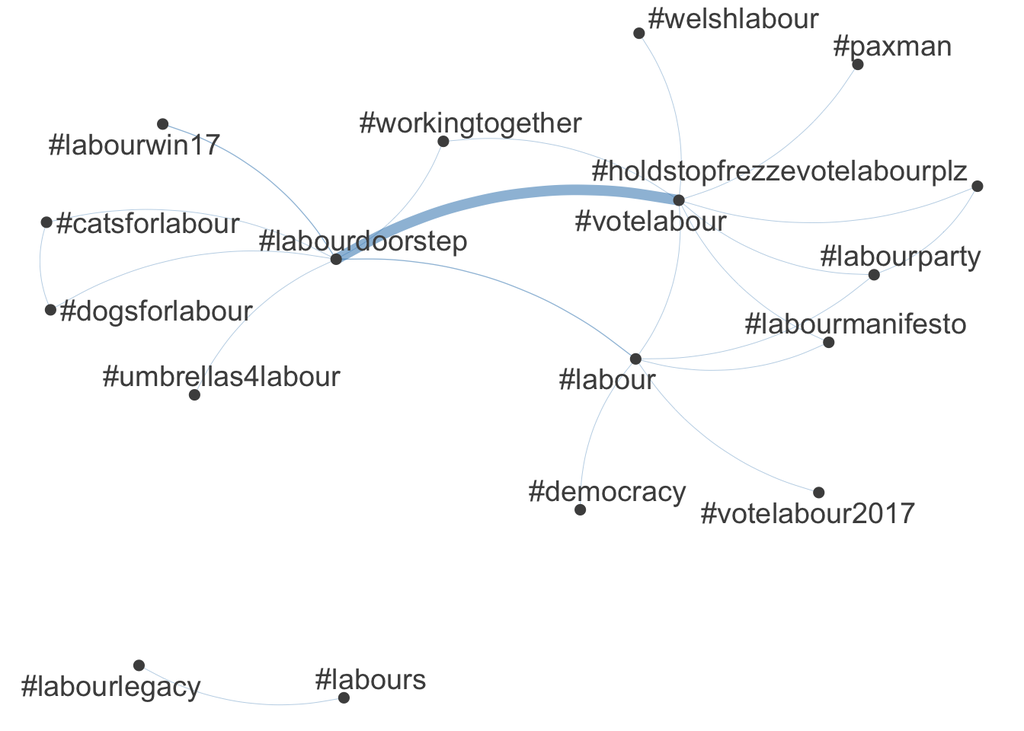

```r
toks <- tweets_3$text %>%
    tokens(remove_punct = TRUE) %>%
    tokens_tolower() %>%
    tokens_remove(pattern = stopwords("english"), padding = FALSE)
fcmat <- fcm(toks, context = "window", tri = FALSE)
fcm_select(fcmat, pattern = "#*") %>%
  fcm_select(pattern = c("*man","*labo*" ,"*work*","*male*","*demo*"))%>%
  textplot_network()
```

**Exercise 4. (30 points)**

In this open-ended exercise, the task is to study building an own database from multiple data sources which stores data on a topic you are interested in. You can e.g. download data with your browser (using APIs has no impact on the grade in this exercise) from data sources mentioned in previous assignments such as the [World Bank](https://data.worldbank.org/), [World Health Organization](https://www.who.int/data/gho), [St. Louis Federal Reserve](https://fred.stlouisfed.org/), [Our World in Data](https://ourworldindata.org/), and/or the [World Inequality Database](https://wid.world/data/). After downloading the data, reshape and process it with R packages such as `dplyr`, and then store the final tables in an `SQLite` database. This database should contain at least 2 tables.

More extensive, thought out, polished, and complex databases that combine data from different sources will receive higher marks here. Note, however, that the database should not be unnecessarily complex. For example, it would not make sense to store each economic indicator time-series in a separate table of a database. Rather, data should conceptually be bundled in tables. Also make sure not to repeat any unnecessary duplicate information in different tables of the database (e.g. in a hypothetical university database with a `students` and an `exams` table, both tables contain a `studentid` column but - because the tables can be joined via this column whenever necessary - the `exams` table does not repeat the student email addresses and other student information which is already stored in the `students` table).

If the final database is large, you can simply store it (and load it from) outside of the repository since we will grade the knitted HTML file. Database files can be uploaded to GitHub, however, note that if the database is large, GitHub push/pulls will be slower.

Download and process the data, then store it in the final `SQLite` database. Describe in markdown text why you structured the database the way you did. Then use SQL queries to:

1. Print out the total number of rows for each table in your database. Print out the column names for each table.
2. Print out the first 10 rows for each table.
3. Show whether all tables in the database can be (directly or indirectly) joined with SQL queries. Print out the first 5 rows of the joined tables.

```r
# 4
# Create database
db4 <- dbConnect(RSQLite::SQLite(), "~/downloads/assignment05_4/assignment05_4.sqlite")

# Reading the all the files into R
text04 <- readtext('~/downloads/assignment05_4',ignore_missing_files=TRUE,text_field = NULL)
# Extract columns related to economic conditions
econ_tp <- text04[c(3:221),c(4:11)] %>%
  as.data.frame()

# Extract columns related to economic health
econ_health_tp <- text04[c(227:375),c(5,13)] %>%
  as.data.frame()

# Join these two tables related to econ
econ_all_tp = full_join(econ_tp, econ_health_tp,by = "Country.Code") %>%
  format(scientific = F) # turn down the scientific notation

# Extract columns related to education condition
edu_tp <- text04[c(381:622),c(5,14:35)] %>%
  distinct(Country.Code,.keep_all = TRUE) %>%
  as.data.frame() %>%
  format(scientific = F)

# Extract columns related to fortune condition
fortune_tp <- text04[c(628:773),c(5,37:44)] %>%
  distinct(Country.Code,.keep_all = TRUE) %>%
  as.data.frame() %>%
  format(scientific = F)

# Extract columns related to health condition
health_tp <- text04[c(779:1044),c(5,46:53)] %>%
  distinct(Country.Code,.keep_all = TRUE) %>%
  as.data.frame() %>%
  format(scientific = F)

# Write in database
dbWriteTable(db4, "econ", econ_all_tp)
dbWriteTable(db4, "edu", edu_tp)
dbWriteTable(db4, "fortune", fortune_tp)
dbWriteTable(db4, "health", health_tp)

# use to remove
#dbRemoveTable(db4, "econ")
#dbRemoveTable(db4, "edu")
#dbRemoveTable(db4, "fortune")
#dbRemoveTable(db4, "health")

# 5.1
# Print out the total number of rows

dbGetQuery(db4, "SELECT COUNT(*) FROM econ")
```

```
##   COUNT(*)
## 1      223
```

```r
dbGetQuery(db4, "SELECT COUNT(*) FROM edu")
```

```
##   COUNT(*)
## 1      242
```

```r
dbGetQuery(db4, "SELECT COUNT(*) FROM fortune")
```

```
##   COUNT(*)
## 1      146
```

```r
dbGetQuery(db4, "SELECT COUNT(*) FROM health")
```

```
##   COUNT(*)
## 1      266
```

```r
# Print out the column names for each table
print("column names in econ")
```

```
## [1] "column names in econ"
```

```r
dbListFields(db4, "econ")
```

```
## [1] "Country"
## [2] "Country.Code"
## [3] "GDP.current.US..millions.seas..adj....NYGDPMKTPSACD."
## [4] "Industrial.Production..constant.US...seas..adj.....IPTOTSAKD."
## [5] "Stock.Markets..US......DSTKMKTXD."
## [6] "Unemployment.rate.Percent.....UNEMPSA_."
## [7] "Exchange.rate..new.LCU.per.USD.extended.backward..period.average....DPANUSSPB."
## [8] "Core.CPI.not.seas.adj.....CORENS."
## [9] "Economic.Fitness.Metric..Legacy...EF.EFM.OVRL.XD."
```

```r
print("column names in edu")
```

```
## [1] "column names in edu"
```

```r
dbListFields(db4, "edu")
```

```
##  [1] "Country.Code"
##  [2] "Literacy.rate..adult.male....of.males.ages.15.and.above...SE.ADT.LITR.MA.ZS."
##  [3] "Literacy.rate..adult.female....of.females.ages.15.and.above...SE.ADT.LITR.FE.ZS."
##  [4] "Labor.force.participation.rate..male....of.male.population.ages.15....modeled.ILO.estimate...SL.TLF.CACT.MA.ZS."
##  [5] "Labor.force.participation.rate..female....of.female.population.ages.15....modeled.ILO.estimate...SL.TLF.CACT.FE.ZS."
##  [6] "Employment.in.services..female....of.female.employment...modeled.ILO.estimate...SL.SRV.EMPL.FE.ZS."
##  [7] "Employment.in.services..male....of.male.employment...modeled.ILO.estimate...SL.SRV.EMPL.MA.ZS."
##  [8] "Employment.in.industry..male....of.male.employment...modeled.ILO.estimate...SL.IND.EMPL.MA.ZS."
##  [9] "Employment.in.industry..female....of.female.employment...modeled.ILO.estimate...SL.IND.EMPL.FE.ZS."
## [10] "Employment.in.agriculture..male....of.male.employment...modeled.ILO.estimate...SL.AGR.EMPL.MA.ZS."
## [11] "Employment.in.agriculture..female....of.female.employment...modeled.ILO.estimate...SL.AGR.EMPL.FE.ZS."
## [12] "Employers..male....of.male.employment...modeled.ILO.estimate...SL.EMP.MPYR.MA.ZS."
## [13] "Employers..female....of.female.employment...modeled.ILO.estimate...SL.EMP.MPYR.FE.ZS."
## [14] "Adolescent.fertility.rate..births.per.1.000.women.ages.15.19...SP.ADO.TFRT."
## [15] "Labor.force.with.advanced.education..female....of.female.working.age.population.with.advanced.education...SL.TLF.ADVN.FE.ZS."
## [16] "Labor.force.with.advanced.education..male....of.male.working.age.population.with.advanced.education...SL.TLF.ADVN.MA.ZS."
## [17] "Labor.force.with.basic.education..male....of.male.working.age.population.with.basic.education...SL.TLF.BASC.MA.ZS."
## [18] "Labor.force.with.basic.education..female....of.female.working.age.population.with.basic.education...SL.TLF.BASC.FE.ZS."
## [19] "Researchers.in.R.D..per.million.people...SP.POP.SCIE.RD.P6."
## [20] "School.enrollment..primary..female....gross...SE.PRM.ENRR.FE."
## [21] "School.enrollment..primary..male....gross...SE.PRM.ENRR.MA."
## [22] "Unemployment.with.advanced.education..female....of.female.labor.force.with.advanced.education...SL.UEM.ADVN.FE.ZS."
## [23] "Unemployment.with.advanced.education..male....of.male.labor.force.with.advanced.education...SL.UEM.ADVN.MA.ZS."
```

```r
print("column names in fortune")
```

```
## [1] "column names in fortune"
```

```r
dbListFields(db4, "fortune")
```

```
## [1] "Country.Code"
## [2] "Natural.capital..constant.2018.US....NW.NCA.TO."
## [3] "Natural.capital.per.capita..agricultural.land..constant.2018.US....NW.NCA.AGRI.PC."
## [4] "Natural.capital.per.capita..fisheries..constant.2018.US....NW.NCA.FISH.PC."
## [5] "Natural.capital.per.capita..forests..ecosystem.services..constant.2018.US....NW.NCA.FECO.PC."
## [6] "Natural.capital.per.capita..forests..timber..constant.2018.US....NW.NCA.FTIM.PC."
## [7] "Natural.capital.per.capita..fossil.fuels..constant.2018.US....NW.NCA.FOSL.PC."
## [8] "Produced.capital.per.capita..constant.2018.US....NW.PCA.PC."
## [9] "Total.wealth.per.capita..constant.2018.US....NW.TOW.PC."
```

```r
print("column names in health")
```

```
## [1] "column names in health"
```

```r
dbListFields(db4, "health")
```

```
## [1] "Country.Code"
## [2] "Adults..ages.15...living.with.HIV..SH.DYN.AIDS."
## [3] "Capital.health.expenditure....of.GDP...SH.XPD.KHEX.GD.ZS."
## [4] "Number.of.people.who.are.undernourished..SN.ITK.DEFC."
## [5] "Rural.population....of.total.population...SP.RUR.TOTL.ZS."
## [6] "Urban.population..SP.URB.TOTL."
## [7] "Labor.force..total..SL.TLF.TOTL.IN."
## [8] "Incidence.of.malaria..per.1.000.population.at.risk...SH.MLR.INCD.P3."
## [9] "Incidence.of.tuberculosis..per.100.000.people...SH.TBS.INCD."
```

```r
# 5.2
# Print out the first 10 rows for each table
dbGetQuery(db4, "SELECT * FROM econ LIMIT 10")
```

```
##                Country Country.Code
## 1          Afghanistan          AFG
## 2              Albania          ALB
## 3              Algeria          DZA
## 4               Angola          AGO
## 5  Antigua and Barbuda          ATG
## 6            Argentina          ARG
## 7              Armenia          ARM
## 8                Aruba          ABW
## 9            Australia          AUS
## 10             Austria          AUT
##    GDP.current.US..millions.seas..adj....NYGDPMKTPSACD.
## 1                                                    ..
## 2                                      11383.1280708463
## 3                                                    ..
```

[output cut: 62 more lines]

```r
dbGetQuery(db4, "SELECT * FROM edu LIMIT 10")
```

```
##    Country.Code
## 1           AFG
## 2           ALB
## 3           DZA
## 4           ASM
## 5           AND
## 6           AGO
## 7           ATG
## 8           ARB
## 9           ARG
## 10          ARM
##    Literacy.rate..adult.male....of.males.ages.15.and.above...SE.ADT.LITR.MA.ZS.
## 1                                                                            ..
## 2                                                                            ..
## 3                                                                            ..
```

[output cut: 238 more lines]

```r
dbGetQuery(db4, "SELECT * FROM fortune LIMIT 10")
```

```
##    Country.Code Natural.capital..constant.2018.US....NW.NCA.TO.
## 1           ALB                                     25229850088
## 2           ARG                                    668096379187
## 3           ARM                                     16269113130
## 4           AUS                                   2113420761322
## 5           AUT                                    117541868521
## 6           AZE                                    216694557094
## 7           BHR                                     19686947662
## 8           BGD                                    198985166923
## 9           BLR                                     87582152403
## 10          BEL                                     49384498116
##    Natural.capital.per.capita..agricultural.land..constant.2018.US....NW.NCA.AGRI.PC.
## 1                                                                           4876.6183
## 2                                                                           8582.2045
## 3                                                                           3433.9330
```

[output cut: 73 more lines]

```r
dbGetQuery(db4, "SELECT * FROM health LIMIT 10")
```

```
##    Country.Code Adults..ages.15...living.with.HIV..SH.DYN.AIDS.
## 1           AFG                                            6600
## 2           AFE                                              ..
## 3           AFW                                              ..
## 4           ALB                                            1100
## 5           DZA                                           11000
## 6           ASM                                              ..
## 7           AND                                              ..
## 8           AGO                                          260000
## 9           ATG                                              ..
## 10          ARB                                              ..
##    Capital.health.expenditure....of.GDP...SH.XPD.KHEX.GD.ZS.
## 1                                                 0.21357545
## 2                                                         ..
## 3                                                         ..
```

[output cut: 62 more lines]

```r
# 5.3
# All the tables can be jioned directly via country code.
# Print out the first five rows of the joined table (join econ)
dbGetQuery(db4, "SELECT *
           FROM econ
           JOIN edu
           ON econ.'Country.Code' = edu.'Country.Code'
           LIMIT 5")
```

```
##               Country Country.Code
## 1         Afghanistan          AFG
## 2             Albania          ALB
## 3             Algeria          DZA
## 4              Angola          AGO
## 5 Antigua and Barbuda          ATG
##   GDP.current.US..millions.seas..adj....NYGDPMKTPSACD.
## 1                                                   ..
## 2                                     11383.1280708463
## 3                                                   ..
## 4                                                   ..
## 5                                                   ..
##   Industrial.Production..constant.US...seas..adj.....IPTOTSAKD.
## 1                                                            ..
## 2                                                            ..
```

[output cut: 159 more lines]

```r
dbGetQuery(db4, "SELECT *
           FROM econ
           JOIN fortune
           ON econ.'Country.Code' = fortune.'Country.Code'
           LIMIT 5")
```

```
##     Country Country.Code GDP.current.US..millions.seas..adj....NYGDPMKTPSACD.
## 1   Albania          ALB                                     11383.1280708463
## 2 Argentina          ARG                                     642325.617561616
## 3   Armenia          ARM                                     10561.6168314577
## 4 Australia          AUS                                     1233797.52796741
## 5   Austria          AUT                                      382224.05582305
##   Industrial.Production..constant.US...seas..adj.....IPTOTSAKD.
## 1                                                            ..
## 2                                                            ..
## 3                                                            ..
## 4                                                            ..
## 5                                              117216799625.229
##   Stock.Markets..US......DSTKMKTXD. Unemployment.rate.Percent.....UNEMPSA_.
## 1                                ..                                      ..
## 2                   472.52216788637                           6.61156985359
```

[output cut: 69 more lines]

```r
dbGetQuery(db4, "SELECT *
           FROM econ
           JOIN health
           ON econ.'Country.Code' = health.'Country.Code'
           LIMIT 5")
```

```
##               Country Country.Code
## 1         Afghanistan          AFG
## 2             Albania          ALB
## 3             Algeria          DZA
## 4              Angola          AGO
## 5 Antigua and Barbuda          ATG
##   GDP.current.US..millions.seas..adj....NYGDPMKTPSACD.
## 1                                                   ..
## 2                                     11383.1280708463
## 3                                                   ..
## 4                                                   ..
## 5                                                   ..
##   Industrial.Production..constant.US...seas..adj.....IPTOTSAKD.
## 1                                                            ..
## 2                                                            ..
```

[output cut: 69 more lines]

```r
# Print out the first five rows of the joined table (join all)
dbGetQuery(db4, "SELECT *
           FROM econ
           JOIN edu
           ON econ.'Country.Code' = edu.'Country.Code'
           JOIN fortune
           ON econ.'Country.Code' = fortune.'Country.Code'
           JOIN health
           ON econ.'Country.Code' = health.'Country.Code'
           LIMIT 5")
```

```
##     Country Country.Code GDP.current.US..millions.seas..adj....NYGDPMKTPSACD.
## 1   Albania          ALB                                     11383.1280708463
## 2 Argentina          ARG                                     642325.617561616
## 3   Armenia          ARM                                     10561.6168314577
## 4 Australia          AUS                                     1233797.52796741
## 5   Austria          AUT                                      382224.05582305
##   Industrial.Production..constant.US...seas..adj.....IPTOTSAKD.
## 1                                                            ..
## 2                                                            ..
## 3                                                            ..
## 4                                                            ..
## 5                                              117216799625.229
##   Stock.Markets..US......DSTKMKTXD. Unemployment.rate.Percent.....UNEMPSA_.
## 1                                ..                                      ..
## 2                   472.52216788637                           6.61156985359
```

[output cut: 243 more lines]

```r
dbDisconnect(db4)
```

**Answer: This question looks for information about the health, education and natural resources and human resources reserves of each country in the world, using 2015 as the base year (as some data are only recorded up to 2015), where the names of the countries are stored within the economic development situation and the rest of the individual tables are linked by country codes. The reason for this is that I believe that all dimensions cannot be analysed without the context of the economy, so the economy will definitely be added to the analysis. The indicator “economic health” is exotic, but I think it is important，so it has to be added manually to the economic situation table.**